# Reliability - Part 2 : Physical Approach

Vincent Le Goualher

01/03/2020

# 1 Physical approach

In this section, the height of the water level rise is determined by the following model :

$H = (\frac {Q} { K_{s} B \sqrt{ \frac{ Z_{m}-Z_{v} } {L} } })^{ \frac{3}{5} } \qquad (1)$

The height of the seawall is represented by $h_{d}$.

The variables of the above equation are described in the two following sections.

## 1.1 Deterministic variables

Some features of the model are supposed to be deterministic :  
- $L$ : The length of the section of the river taken into consideration. $L = 5 000\ m$.  
- $B$ : The width of the river. $B = 300\ m$.  
- $Z_{b}$ : The height (above sea level) of the riverbank. $Z_{b} = 55.5\ m$.

## 1.2 Random variables and statistical assumptions

The rest of the variables are supposed to be random :  
- $Q$ : The flow of the river in $m^{3}.s^{-1}$. $Q \sim Gumbel(\ mode=1013,\ scale=558 \ )$  
- $K_{s}$ : The river bed coefficient of friction, also known as the Strickler coefficient, in $m^{\frac{1}{3}}.s^{-1}$. $K_{s} \sim \mathcal N(\ \mu=30,\ \sigma=7.5 \ )$  
- $Z_{m},Z_{v}$ : The height (above sea level) of the river bed upstream and downstream. $Z_{m} \sim \mathcal T(\ m=55,\ h=1 \ )$ and $Z_{v} \sim \mathcal T(\ m=50,\ h=1 \ )$ where $\mathcal T(m,\ h)$ is the triangular distribution of mean $m$ and half-range $h$.

Finally, $Z_{c} := H + Z_{v}$ and $Z_{d} := Z_{b} + h_{d}$. $S$, the height of the water above the seawall is defined as follows : $S := Z_{c} - Z_{d} = H + Z_{v} - (Z_{b} + h_{d})$

## 1.3 Taking physical realities into account

The above models assumed for the flow $Q$ and the coefficient of friction $K_{s}$ must be corrected to ensure physical consistency.

### 1.3.1 The flow $Q$

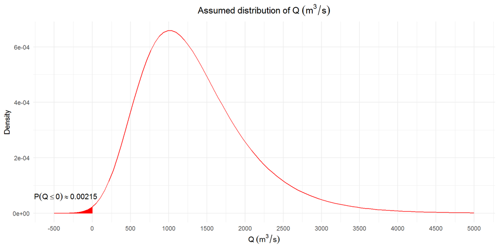

```r
ggplot( tibble(x=(-500:5000)), aes(x) ) +
  stat_function(fun = dgumbel, args = list( loc = 1013,  scale = 558 ), geom = "line", color = "red", size = 0.5) +
  stat_function(fun = dgumbel, args = list( loc = 1013,  scale = 558 ), xlim = c(-500,0), geom = "area", color = "red", fill = "red") +
  annotate( "text", x = -350, y = 6e-5, label = expression( P(Q <= 0) %~~% 0.00215 ) ) +
  xlab( expression(Q~(m^3/s)) ) +
  scale_x_continuous( breaks = seq(-500, 5000, by=500) ) +
  ylab("Density") +
  theme_minimal() +
  ggtitle( expression(Assumed~distribution~of~Q~(m^3/s)) ) +
  theme( plot.title = element_text(hjust = 0.5) )
```

As a flow, $Q \geq 0$. Yet if $Q \sim Gumbel(\ mode=1013,\ scale=558 \ )$, then $\mathbb{P}(Q \leq 0) \approx 0.00215$. For the simulation in the next section, we will set $Q=0$ if the simulation gives $Q < 0$. Hence $Q$ actually becomes a mixed random variable on $[0;+\infty]$: the density of $Q$ is equal to the density $Gumbel(\ mode=1013,\ scale=558 \ )$ on $]0;+ \infty[$, and $\mathbb{P}(Q = 0) \approx 0.00215$.

### 1.3.2 The Strickler coefficient $K_{s}$

In **Hydraulics of Open Channel Flow$** by Hubert Chanson, it is said that the Strickler coefficient “varies from 20 (rough stone and rough surface) to 80 m<sup>1/3</sup>/s (smooth concrete and cast iron)”. However, the assumed distribution for the coefficient $K_{s}$ intentionally allows it to be greater or lower than these limits. The reason for this choice is that in the equation $(1)$, the purpose of $K_{s}$ is also to bring noise into the variable H in order to model non-represented phenomena. Having said that, $K_s$ cannot be less than or equal to 0, given the equation $(1)$.

Hence we make the assumption $K_s \geq q_{10^{-4}}$, where $\mathbb{P}(X \leq q_{10^{-4}}) = 10^{-4}$ and $X \sim \mathcal N(\ \mu=30,\ \sigma=7.5 \ )$.  
$q_{10^{-4}}\approx 2.1014$. Finally, the distribution of $K_s$ is supposed to be a truncated normal law :

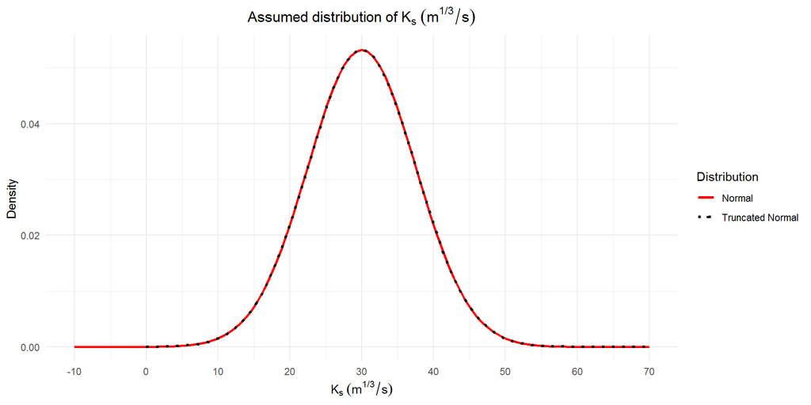

```r
ggplot( tibble(x=(-10:70)), aes(x) ) +
  stat_function(fun = dnorm,
                args = list( mean = 30,  sd = 7.5 ),
                geom = "line",
                aes(color = "red", linetype = "solid"),
                size = 1) +
  stat_function(fun = dtruncnorm,
                args = list( a = qnorm(1e-4, mean=30, sd=7.5, lower.tail = TRUE), b = Inf, mean = 30, sd = 7.5 ),
                xlim = c(0,70),
                geom = "line",
                aes(color = "black", linetype = "dotted"),
                size = 1.2) +
  scale_color_identity(name = "Distribution", breaks = c("red", "black"), labels = c("Normal", "Truncated Normal"), guide = "legend") +
  scale_linetype_identity(name = "Distribution", breaks = c("solid", "dotted"), labels = c("Normal", "Truncated Normal"), guide = "legend") +
  scale_x_continuous( breaks = seq(-10,70,by=10) ) +
  xlab( expression(K[s]~(m^paste(1,'/',3) /s)) ) +
  ylab("Density") +
  theme_minimal() +
  ggtitle( expression(Assumed~distribution~of~K[s]~(m^paste(1,'/',3) /s)) ) +
  theme( plot.title = element_text(hjust = 0.5) )
```

The normal law and the truncated normal law are very similar because the cut is made far from the mean $\mu = 30$, at $q_{10^{-4}}\approx 2.1014$. Thus this adjustement will have minor consequences on the modeling of $K_s$, while avoiding undefined, infinite and absurdly high values for the variable H in equation $(1)$.

## 1.4 Simulation of the height of water above the riverbank

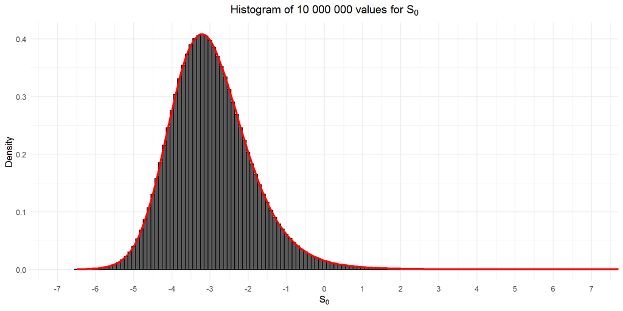

```r
set.seed(66)

n <- 1e7

l <- 5000
b <- 300
zb <- 55.5

don <- tibble(
  q = rgumbel( n = n, loc = 1013, scale = 558 ),
  ks = rtruncnorm( n = n, a = qnorm(1e-4, mean=30, sd=7.5, lower.tail = TRUE), b = Inf, mean = 30, sd = 7.5 ),
  zm = rtri(n, min = 54, max = 56, mode = 55),
  zv = rtri(n, min = 49, max = 51, mode = 50),
) %>%
mutate(
  q = if_else( q <= 0, 0, q),
  s0 = ( q / ( ks * b * sqrt( (zm - zv) / l) ) )^(3/5) + zv - zb
)

s0 <- don %>% pull(s0)

ggplot( data = don ) +
  geom_histogram( aes( x = s0, stat(density) ), binwidth = 0.1, color = "black" ) +
  stat_density( aes( x = s0 ), geom = "line", color = "red", size = 1.1 ) +
  coord_cartesian( xlim = c(-7,7) ) +
  xlab( expression("S"[0]) ) +
  scale_x_continuous( breaks = seq(-10,10,by=1) ) +
  ylab( "Density" ) +
  theme_minimal() +
  ggtitle( expression("Histogram of 10 000 000 values for S"[0]) ) +
  theme( plot.title = element_text(hjust = 0.5) )
```

We now give the quantiles of the distribution of $S_0$ for the probability 0.9, 0.99 and so forth :

```r
quantiles <- tibble(
  power = 1:6,
  probability = str_c('1 - 10^(-', power, ')'),
  quantile = s0 %>% quantile( 1 - 10^(-power) ) %>% as.double() %>% round(2) %>% as.character() %>% str_c(" m")
) %>%
  select(-power)

quantiles %>%
  kable( caption = "Quantiles for the height of the water over the riverbank over 10 000 000 simulations" ) %>%
  kable_styling(
    full_width = T,
    position = 'center',
    bootstrap_options = c("striped", "hover")
  )
```

Quantiles for the height of the water over the riverbank over 10 000 000 simulations

| probability | quantile |
| --- | --- |
| 1 - 10^(-1) | -1.6 m |
| 1 - 10^(-2) | 0.12 m |
| 1 - 10^(-3) | 2.17 m |
| 1 - 10^(-4) | 5.36 m |
| 1 - 10^(-5) | 10.08 m |
| 1 - 10^(-6) | 14.27 m |